# Lab 4: Evaluation and Multi-Layer Perceptron

Members:  
CSE 5324: Shenxiao Mei, Samuel Lefcourt

## Preparation and Overview

The quality of red wine is determined by many factors. Because each red wine has components in different concentration, the red wine is likely to taste differently from brand to brand. A red wine connoisseur can usually tell the age, the quality, maybe even the name of the wine. People who know how to examine the quality of a red wine are usually considered elegant and noble. Sometimes, if people know nothing about wine, they will probably purchase red wine in bad quality for their grand event. If people just want to throw a small party, it is unwise to buy the best red wine. To solve this problem, in this lab, we will use a machine learning training model to become the wine connoisseur. We will use a dataset of red wine. This dataset is related to red variants of the Portuguese "Vinho Verde" wine. In our training process, we will classify the red wines into three quality classes: "Good", "Medium", and "Bad".

Like mentioned earlier, any party host will be interested in our results. Using our results, he/she will have freedom to choose the quality of wine for the upcoming party. Also, any wine taster will be interested in our product because it can be used to train his/her tastebuds. Most importantly, red wine manufacturers will be interested so that they can know what quality they have and know how to improve the quality by adjusting the recipe.

Our training model will mainly be deployed in real-time because the whole dataset is the same type of wine and our model is just for this specific brand. The quality or grade varies by time and storing condition.

Source: **https://www.kaggle.com/uciml/red-wine-quality-cortez-et-al-2009**

### Measure of Success

Our prediction task will be to "grade" the different red wine. Despite wine experts lauding their tastebuds and elevated senses, a study conducted by Robert Hodgson proved otherwise. He approached the organizers of the California state fair wine competition and asked them to present judges with different samples from the same bottle three times. Normally, judges scale a wine from range 50-100. He claims the results were "disturbing". After giving the judges samples from the same wine bottle, he found that they each scored it differently each time! Ranging from low 80s to high 90s, the expert judges (winemakers, sommeliers, critics and wine consultants and academics) were highly inconsistent. He further went on to say that objectively evaluating large numbers of wines as currently attempted at wine competitions is, "beyond human ability". Due to this fact that not even "experts" can consistently and accurately identify and grade wines, our goal is to reach 70% accuracy.

**However, we will not use accuracy as metrics in THIS LAB. We will build a customized weighted accuracy metrics**  
**We will consider our score lower than 0.7 because we set a punishment score for classify bad quality wine to good quality wine**

Source: **https://www.theguardian.com/lifeandstyle/2013/jun/23/wine-tasting-junk-science-analysis** and **https://en.wikipedia.org/wiki/Blind_wine_tasting**

```python
import pandas as pd
import numpy as np

print('Pandas:', pd.__version__)
print('Numpy:',np.__version__)

df = pd.read_csv('data/winequality-red.csv') # read in the csv file

df.info()
df.head()
df
```

```
Pandas: 0.24.0
Numpy: 1.15.4
<class 'pandas.core.frame.DataFrame'>
RangeIndex: 1599 entries, 0 to 1598
Data columns (total 12 columns):
fixed acidity           1599 non-null float64
volatile acidity        1599 non-null float64
citric acid             1599 non-null float64
residual sugar          1599 non-null float64
chlorides               1599 non-null float64
free sulfur dioxide     1599 non-null float64
total sulfur dioxide    1599 non-null float64
density                 1599 non-null float64
pH                      1599 non-null float64
sulphates               1599 non-null float64
alcohol                 1599 non-null float64
quality                 1599 non-null int64
dtypes: float64(11), int64(1)
memory usage: 150.0 KB
```

|  | fixed acidity | volatile acidity | citric acid | residual sugar | chlorides | free sulfur dioxide | total sulfur dioxide | density | pH | sulphates | alcohol | quality |
| --- | --- | --- | --- | --- | --- | --- | --- | --- | --- | --- | --- | --- |
| 0 | 7.4 | 0.700 | 0.00 | 1.9 | 0.076 | 11.0 | 34.0 | 0.99780 | 3.51 | 0.56 | 9.4 | 5 |
| 1 | 7.8 | 0.880 | 0.00 | 2.6 | 0.098 | 25.0 | 67.0 | 0.99680 | 3.20 | 0.68 | 9.8 | 5 |
| 2 | 7.8 | 0.760 | 0.04 | 2.3 | 0.092 | 15.0 | 54.0 | 0.99700 | 3.26 | 0.65 | 9.8 | 5 |
| 3 | 11.2 | 0.280 | 0.56 | 1.9 | 0.075 | 17.0 | 60.0 | 0.99800 | 3.16 | 0.58 | 9.8 | 6 |
| 4 | 7.4 | 0.700 | 0.00 | 1.9 | 0.076 | 11.0 | 34.0 | 0.99780 | 3.51 | 0.56 | 9.4 | 5 |
| 5 | 7.4 | 0.660 | 0.00 | 1.8 | 0.075 | 13.0 | 40.0 | 0.99780 | 3.51 | 0.56 | 9.4 | 5 |
| 6 | 7.9 | 0.600 | 0.06 | 1.6 | 0.069 | 15.0 | 59.0 | 0.99640 | 3.30 | 0.46 | 9.4 | 5 |
| 7 | 7.3 | 0.650 | 0.00 | 1.2 | 0.065 | 15.0 | 21.0 | 0.99460 | 3.39 | 0.47 | 10.0 | 7 |
| 8 | 7.8 | 0.580 | 0.02 | 2.0 | 0.073 | 9.0 | 18.0 | 0.99680 | 3.36 | 0.57 | 9.5 | 7 |
| 9 | 7.5 | 0.500 | 0.36 | 6.1 | 0.071 | 17.0 | 102.0 | 0.99780 | 3.35 | 0.80 | 10.5 | 5 |
| 10 | 6.7 | 0.580 | 0.08 | 1.8 | 0.097 | 15.0 | 65.0 | 0.99590 | 3.28 | 0.54 | 9.2 | 5 |
| 11 | 7.5 | 0.500 | 0.36 | 6.1 | 0.071 | 17.0 | 102.0 | 0.99780 | 3.35 | 0.80 | 10.5 | 5 |
| 12 | 5.6 | 0.615 | 0.00 | 1.6 | 0.089 | 16.0 | 59.0 | 0.99430 | 3.58 | 0.52 | 9.9 | 5 |
| 13 | 7.8 | 0.610 | 0.29 | 1.6 | 0.114 | 9.0 | 29.0 | 0.99740 | 3.26 | 1.56 | 9.1 | 5 |
| 14 | 8.9 | 0.620 | 0.18 | 3.8 | 0.176 | 52.0 | 145.0 | 0.99860 | 3.16 | 0.88 | 9.2 | 5 |
| 15 | 8.9 | 0.620 | 0.19 | 3.9 | 0.170 | 51.0 | 148.0 | 0.99860 | 3.17 | 0.93 | 9.2 | 5 |
| 16 | 8.5 | 0.280 | 0.56 | 1.8 | 0.092 | 35.0 | 103.0 | 0.99690 | 3.30 | 0.75 | 10.5 | 7 |
| 17 | 8.1 | 0.560 | 0.28 | 1.7 | 0.368 | 16.0 | 56.0 | 0.99680 | 3.11 | 1.28 | 9.3 | 5 |
| 18 | 7.4 | 0.590 | 0.08 | 4.4 | 0.086 | 6.0 | 29.0 | 0.99740 | 3.38 | 0.50 | 9.0 | 4 |
| 19 | 7.9 | 0.320 | 0.51 | 1.8 | 0.341 | 17.0 | 56.0 | 0.99690 | 3.04 | 1.08 | 9.2 | 6 |
| 20 | 8.9 | 0.220 | 0.48 | 1.8 | 0.077 | 29.0 | 60.0 | 0.99680 | 3.39 | 0.53 | 9.4 | 6 |
| 21 | 7.6 | 0.390 | 0.31 | 2.3 | 0.082 | 23.0 | 71.0 | 0.99820 | 3.52 | 0.65 | 9.7 | 5 |
| 22 | 7.9 | 0.430 | 0.21 | 1.6 | 0.106 | 10.0 | 37.0 | 0.99660 | 3.17 | 0.91 | 9.5 | 5 |
| 23 | 8.5 | 0.490 | 0.11 | 2.3 | 0.084 | 9.0 | 67.0 | 0.99680 | 3.17 | 0.53 | 9.4 | 5 |
| 24 | 6.9 | 0.400 | 0.14 | 2.4 | 0.085 | 21.0 | 40.0 | 0.99680 | 3.43 | 0.63 | 9.7 | 6 |
| 25 | 6.3 | 0.390 | 0.16 | 1.4 | 0.080 | 11.0 | 23.0 | 0.99550 | 3.34 | 0.56 | 9.3 | 5 |
| 26 | 7.6 | 0.410 | 0.24 | 1.8 | 0.080 | 4.0 | 11.0 | 0.99620 | 3.28 | 0.59 | 9.5 | 5 |
| 27 | 7.9 | 0.430 | 0.21 | 1.6 | 0.106 | 10.0 | 37.0 | 0.99660 | 3.17 | 0.91 | 9.5 | 5 |
| 28 | 7.1 | 0.710 | 0.00 | 1.9 | 0.080 | 14.0 | 35.0 | 0.99720 | 3.47 | 0.55 | 9.4 | 5 |
| 29 | 7.8 | 0.645 | 0.00 | 2.0 | 0.082 | 8.0 | 16.0 | 0.99640 | 3.38 | 0.59 | 9.8 | 6 |
| ... | ... | ... | ... | ... | ... | ... | ... | ... | ... | ... | ... | ... |
| 1569 | 6.2 | 0.510 | 0.14 | 1.9 | 0.056 | 15.0 | 34.0 | 0.99396 | 3.48 | 0.57 | 11.5 | 6 |
| 1570 | 6.4 | 0.360 | 0.53 | 2.2 | 0.230 | 19.0 | 35.0 | 0.99340 | 3.37 | 0.93 | 12.4 | 6 |
| 1571 | 6.4 | 0.380 | 0.14 | 2.2 | 0.038 | 15.0 | 25.0 | 0.99514 | 3.44 | 0.65 | 11.1 | 6 |
| 1572 | 7.3 | 0.690 | 0.32 | 2.2 | 0.069 | 35.0 | 104.0 | 0.99632 | 3.33 | 0.51 | 9.5 | 5 |
| 1573 | 6.0 | 0.580 | 0.20 | 2.4 | 0.075 | 15.0 | 50.0 | 0.99467 | 3.58 | 0.67 | 12.5 | 6 |
| 1574 | 5.6 | 0.310 | 0.78 | 13.9 | 0.074 | 23.0 | 92.0 | 0.99677 | 3.39 | 0.48 | 10.5 | 6 |
| 1575 | 7.5 | 0.520 | 0.40 | 2.2 | 0.060 | 12.0 | 20.0 | 0.99474 | 3.26 | 0.64 | 11.8 | 6 |
| 1576 | 8.0 | 0.300 | 0.63 | 1.6 | 0.081 | 16.0 | 29.0 | 0.99588 | 3.30 | 0.78 | 10.8 | 6 |
| 1577 | 6.2 | 0.700 | 0.15 | 5.1 | 0.076 | 13.0 | 27.0 | 0.99622 | 3.54 | 0.60 | 11.9 | 6 |
| 1578 | 6.8 | 0.670 | 0.15 | 1.8 | 0.118 | 13.0 | 20.0 | 0.99540 | 3.42 | 0.67 | 11.3 | 6 |
| 1579 | 6.2 | 0.560 | 0.09 | 1.7 | 0.053 | 24.0 | 32.0 | 0.99402 | 3.54 | 0.60 | 11.3 | 5 |
| 1580 | 7.4 | 0.350 | 0.33 | 2.4 | 0.068 | 9.0 | 26.0 | 0.99470 | 3.36 | 0.60 | 11.9 | 6 |
| 1581 | 6.2 | 0.560 | 0.09 | 1.7 | 0.053 | 24.0 | 32.0 | 0.99402 | 3.54 | 0.60 | 11.3 | 5 |
| 1582 | 6.1 | 0.715 | 0.10 | 2.6 | 0.053 | 13.0 | 27.0 | 0.99362 | 3.57 | 0.50 | 11.9 | 5 |
| 1583 | 6.2 | 0.460 | 0.29 | 2.1 | 0.074 | 32.0 | 98.0 | 0.99578 | 3.33 | 0.62 | 9.8 | 5 |
| 1584 | 6.7 | 0.320 | 0.44 | 2.4 | 0.061 | 24.0 | 34.0 | 0.99484 | 3.29 | 0.80 | 11.6 | 7 |
| 1585 | 7.2 | 0.390 | 0.44 | 2.6 | 0.066 | 22.0 | 48.0 | 0.99494 | 3.30 | 0.84 | 11.5 | 6 |
| 1586 | 7.5 | 0.310 | 0.41 | 2.4 | 0.065 | 34.0 | 60.0 | 0.99492 | 3.34 | 0.85 | 11.4 | 6 |
| 1587 | 5.8 | 0.610 | 0.11 | 1.8 | 0.066 | 18.0 | 28.0 | 0.99483 | 3.55 | 0.66 | 10.9 | 6 |
| 1588 | 7.2 | 0.660 | 0.33 | 2.5 | 0.068 | 34.0 | 102.0 | 0.99414 | 3.27 | 0.78 | 12.8 | 6 |
| 1589 | 6.6 | 0.725 | 0.20 | 7.8 | 0.073 | 29.0 | 79.0 | 0.99770 | 3.29 | 0.54 | 9.2 | 5 |
| 1590 | 6.3 | 0.550 | 0.15 | 1.8 | 0.077 | 26.0 | 35.0 | 0.99314 | 3.32 | 0.82 | 11.6 | 6 |
| 1591 | 5.4 | 0.740 | 0.09 | 1.7 | 0.089 | 16.0 | 26.0 | 0.99402 | 3.67 | 0.56 | 11.6 | 6 |
| 1592 | 6.3 | 0.510 | 0.13 | 2.3 | 0.076 | 29.0 | 40.0 | 0.99574 | 3.42 | 0.75 | 11.0 | 6 |
| 1593 | 6.8 | 0.620 | 0.08 | 1.9 | 0.068 | 28.0 | 38.0 | 0.99651 | 3.42 | 0.82 | 9.5 | 6 |
| 1594 | 6.2 | 0.600 | 0.08 | 2.0 | 0.090 | 32.0 | 44.0 | 0.99490 | 3.45 | 0.58 | 10.5 | 5 |
| 1595 | 5.9 | 0.550 | 0.10 | 2.2 | 0.062 | 39.0 | 51.0 | 0.99512 | 3.52 | 0.76 | 11.2 | 6 |
| 1596 | 6.3 | 0.510 | 0.13 | 2.3 | 0.076 | 29.0 | 40.0 | 0.99574 | 3.42 | 0.75 | 11.0 | 6 |
| 1597 | 5.9 | 0.645 | 0.12 | 2.0 | 0.075 | 32.0 | 44.0 | 0.99547 | 3.57 | 0.71 | 10.2 | 5 |
| 1598 | 6.0 | 0.310 | 0.47 | 3.6 | 0.067 | 18.0 | 42.0 | 0.99549 | 3.39 | 0.66 | 11.0 | 6 |

1599 rows × 12 columns

### Data Understanding

- fixed acidity(float): the fixed acidity of most acids involved with wine
- volatile(float): the amount of acetic acid in wine, which at too high of levels can lead to an unpleasant, vinegar taste
- citric acid(float): found in small quantities, citric acid can add 'freshness' and flavor to wines
- residual sugar(float): the amount of sugar remaining after fermentation stops
- chlorides(float): the amount of salt in the wine
- free sulfur dioxide(float): the free form of SO2 exists in equilibrium between molecular SO2 (as a dissolved gas) and bisulfite ion
- total sulfur dioxide(float): amount of free and bound forms of S02
- density(float): the density of water is close to that of water depending on the percent alcohol and sugar content
- pH(float): describes how acidic or basic a wine is on a scale from 0 (very acidic) to 14 (very basic)
- sulphates(float): a wine additive which can contribute to sulfur dioxide gas (S02) level
- alcohol(float): the percent alcohol content of the wine
- quality(int,ordinal): The actual quality of the wine, ranging from 0-10 (This will be dropped)
- class(int,ordinal): Our prediction, there are three classes: 0, 1, 2. (This is our prediction task)

### Data Cleaning

```python
df=df.drop_duplicates(subset=None, keep='first', inplace=False)
df=df.reset_index()
if 'index' in df:
    del df['index']
df
```

|  | fixed acidity | volatile acidity | citric acid | residual sugar | chlorides | free sulfur dioxide | total sulfur dioxide | density | pH | sulphates | alcohol | quality |
| --- | --- | --- | --- | --- | --- | --- | --- | --- | --- | --- | --- | --- |
| 0 | 7.4 | 0.700 | 0.00 | 1.9 | 0.076 | 11.0 | 34.0 | 0.99780 | 3.51 | 0.56 | 9.4 | 5 |
| 1 | 7.8 | 0.880 | 0.00 | 2.6 | 0.098 | 25.0 | 67.0 | 0.99680 | 3.20 | 0.68 | 9.8 | 5 |
| 2 | 7.8 | 0.760 | 0.04 | 2.3 | 0.092 | 15.0 | 54.0 | 0.99700 | 3.26 | 0.65 | 9.8 | 5 |
| 3 | 11.2 | 0.280 | 0.56 | 1.9 | 0.075 | 17.0 | 60.0 | 0.99800 | 3.16 | 0.58 | 9.8 | 6 |
| 4 | 7.4 | 0.660 | 0.00 | 1.8 | 0.075 | 13.0 | 40.0 | 0.99780 | 3.51 | 0.56 | 9.4 | 5 |
| 5 | 7.9 | 0.600 | 0.06 | 1.6 | 0.069 | 15.0 | 59.0 | 0.99640 | 3.30 | 0.46 | 9.4 | 5 |
| 6 | 7.3 | 0.650 | 0.00 | 1.2 | 0.065 | 15.0 | 21.0 | 0.99460 | 3.39 | 0.47 | 10.0 | 7 |
| 7 | 7.8 | 0.580 | 0.02 | 2.0 | 0.073 | 9.0 | 18.0 | 0.99680 | 3.36 | 0.57 | 9.5 | 7 |
| 8 | 7.5 | 0.500 | 0.36 | 6.1 | 0.071 | 17.0 | 102.0 | 0.99780 | 3.35 | 0.80 | 10.5 | 5 |
| 9 | 6.7 | 0.580 | 0.08 | 1.8 | 0.097 | 15.0 | 65.0 | 0.99590 | 3.28 | 0.54 | 9.2 | 5 |
| 10 | 5.6 | 0.615 | 0.00 | 1.6 | 0.089 | 16.0 | 59.0 | 0.99430 | 3.58 | 0.52 | 9.9 | 5 |
| 11 | 7.8 | 0.610 | 0.29 | 1.6 | 0.114 | 9.0 | 29.0 | 0.99740 | 3.26 | 1.56 | 9.1 | 5 |
| 12 | 8.9 | 0.620 | 0.18 | 3.8 | 0.176 | 52.0 | 145.0 | 0.99860 | 3.16 | 0.88 | 9.2 | 5 |
| 13 | 8.9 | 0.620 | 0.19 | 3.9 | 0.170 | 51.0 | 148.0 | 0.99860 | 3.17 | 0.93 | 9.2 | 5 |
| 14 | 8.5 | 0.280 | 0.56 | 1.8 | 0.092 | 35.0 | 103.0 | 0.99690 | 3.30 | 0.75 | 10.5 | 7 |
| 15 | 8.1 | 0.560 | 0.28 | 1.7 | 0.368 | 16.0 | 56.0 | 0.99680 | 3.11 | 1.28 | 9.3 | 5 |
| 16 | 7.4 | 0.590 | 0.08 | 4.4 | 0.086 | 6.0 | 29.0 | 0.99740 | 3.38 | 0.50 | 9.0 | 4 |
| 17 | 7.9 | 0.320 | 0.51 | 1.8 | 0.341 | 17.0 | 56.0 | 0.99690 | 3.04 | 1.08 | 9.2 | 6 |
| 18 | 8.9 | 0.220 | 0.48 | 1.8 | 0.077 | 29.0 | 60.0 | 0.99680 | 3.39 | 0.53 | 9.4 | 6 |
| 19 | 7.6 | 0.390 | 0.31 | 2.3 | 0.082 | 23.0 | 71.0 | 0.99820 | 3.52 | 0.65 | 9.7 | 5 |
| 20 | 7.9 | 0.430 | 0.21 | 1.6 | 0.106 | 10.0 | 37.0 | 0.99660 | 3.17 | 0.91 | 9.5 | 5 |
| 21 | 8.5 | 0.490 | 0.11 | 2.3 | 0.084 | 9.0 | 67.0 | 0.99680 | 3.17 | 0.53 | 9.4 | 5 |
| 22 | 6.9 | 0.400 | 0.14 | 2.4 | 0.085 | 21.0 | 40.0 | 0.99680 | 3.43 | 0.63 | 9.7 | 6 |
| 23 | 6.3 | 0.390 | 0.16 | 1.4 | 0.080 | 11.0 | 23.0 | 0.99550 | 3.34 | 0.56 | 9.3 | 5 |
| 24 | 7.6 | 0.410 | 0.24 | 1.8 | 0.080 | 4.0 | 11.0 | 0.99620 | 3.28 | 0.59 | 9.5 | 5 |
| 25 | 7.1 | 0.710 | 0.00 | 1.9 | 0.080 | 14.0 | 35.0 | 0.99720 | 3.47 | 0.55 | 9.4 | 5 |
| 26 | 7.8 | 0.645 | 0.00 | 2.0 | 0.082 | 8.0 | 16.0 | 0.99640 | 3.38 | 0.59 | 9.8 | 6 |
| 27 | 6.7 | 0.675 | 0.07 | 2.4 | 0.089 | 17.0 | 82.0 | 0.99580 | 3.35 | 0.54 | 10.1 | 5 |
| 28 | 6.9 | 0.685 | 0.00 | 2.5 | 0.105 | 22.0 | 37.0 | 0.99660 | 3.46 | 0.57 | 10.6 | 6 |
| 29 | 8.3 | 0.655 | 0.12 | 2.3 | 0.083 | 15.0 | 113.0 | 0.99660 | 3.17 | 0.66 | 9.8 | 5 |
| ... | ... | ... | ... | ... | ... | ... | ... | ... | ... | ... | ... | ... |
| 1329 | 6.7 | 0.160 | 0.64 | 2.1 | 0.059 | 24.0 | 52.0 | 0.99494 | 3.34 | 0.71 | 11.2 | 6 |
| 1330 | 7.0 | 0.560 | 0.13 | 1.6 | 0.077 | 25.0 | 42.0 | 0.99629 | 3.34 | 0.59 | 9.2 | 5 |
| 1331 | 6.2 | 0.510 | 0.14 | 1.9 | 0.056 | 15.0 | 34.0 | 0.99396 | 3.48 | 0.57 | 11.5 | 6 |
| 1332 | 6.4 | 0.360 | 0.53 | 2.2 | 0.230 | 19.0 | 35.0 | 0.99340 | 3.37 | 0.93 | 12.4 | 6 |
| 1333 | 6.4 | 0.380 | 0.14 | 2.2 | 0.038 | 15.0 | 25.0 | 0.99514 | 3.44 | 0.65 | 11.1 | 6 |
| 1334 | 7.3 | 0.690 | 0.32 | 2.2 | 0.069 | 35.0 | 104.0 | 0.99632 | 3.33 | 0.51 | 9.5 | 5 |
| 1335 | 6.0 | 0.580 | 0.20 | 2.4 | 0.075 | 15.0 | 50.0 | 0.99467 | 3.58 | 0.67 | 12.5 | 6 |
| 1336 | 5.6 | 0.310 | 0.78 | 13.9 | 0.074 | 23.0 | 92.0 | 0.99677 | 3.39 | 0.48 | 10.5 | 6 |
| 1337 | 7.5 | 0.520 | 0.40 | 2.2 | 0.060 | 12.0 | 20.0 | 0.99474 | 3.26 | 0.64 | 11.8 | 6 |
| 1338 | 8.0 | 0.300 | 0.63 | 1.6 | 0.081 | 16.0 | 29.0 | 0.99588 | 3.30 | 0.78 | 10.8 | 6 |
| 1339 | 6.2 | 0.700 | 0.15 | 5.1 | 0.076 | 13.0 | 27.0 | 0.99622 | 3.54 | 0.60 | 11.9 | 6 |
| 1340 | 6.8 | 0.670 | 0.15 | 1.8 | 0.118 | 13.0 | 20.0 | 0.99540 | 3.42 | 0.67 | 11.3 | 6 |
| 1341 | 6.2 | 0.560 | 0.09 | 1.7 | 0.053 | 24.0 | 32.0 | 0.99402 | 3.54 | 0.60 | 11.3 | 5 |
| 1342 | 7.4 | 0.350 | 0.33 | 2.4 | 0.068 | 9.0 | 26.0 | 0.99470 | 3.36 | 0.60 | 11.9 | 6 |
| 1343 | 6.1 | 0.715 | 0.10 | 2.6 | 0.053 | 13.0 | 27.0 | 0.99362 | 3.57 | 0.50 | 11.9 | 5 |
| 1344 | 6.2 | 0.460 | 0.29 | 2.1 | 0.074 | 32.0 | 98.0 | 0.99578 | 3.33 | 0.62 | 9.8 | 5 |
| 1345 | 6.7 | 0.320 | 0.44 | 2.4 | 0.061 | 24.0 | 34.0 | 0.99484 | 3.29 | 0.80 | 11.6 | 7 |
| 1346 | 7.2 | 0.390 | 0.44 | 2.6 | 0.066 | 22.0 | 48.0 | 0.99494 | 3.30 | 0.84 | 11.5 | 6 |
| 1347 | 7.5 | 0.310 | 0.41 | 2.4 | 0.065 | 34.0 | 60.0 | 0.99492 | 3.34 | 0.85 | 11.4 | 6 |
| 1348 | 5.8 | 0.610 | 0.11 | 1.8 | 0.066 | 18.0 | 28.0 | 0.99483 | 3.55 | 0.66 | 10.9 | 6 |
| 1349 | 7.2 | 0.660 | 0.33 | 2.5 | 0.068 | 34.0 | 102.0 | 0.99414 | 3.27 | 0.78 | 12.8 | 6 |
| 1350 | 6.6 | 0.725 | 0.20 | 7.8 | 0.073 | 29.0 | 79.0 | 0.99770 | 3.29 | 0.54 | 9.2 | 5 |
| 1351 | 6.3 | 0.550 | 0.15 | 1.8 | 0.077 | 26.0 | 35.0 | 0.99314 | 3.32 | 0.82 | 11.6 | 6 |
| 1352 | 5.4 | 0.740 | 0.09 | 1.7 | 0.089 | 16.0 | 26.0 | 0.99402 | 3.67 | 0.56 | 11.6 | 6 |
| 1353 | 6.3 | 0.510 | 0.13 | 2.3 | 0.076 | 29.0 | 40.0 | 0.99574 | 3.42 | 0.75 | 11.0 | 6 |
| 1354 | 6.8 | 0.620 | 0.08 | 1.9 | 0.068 | 28.0 | 38.0 | 0.99651 | 3.42 | 0.82 | 9.5 | 6 |
| 1355 | 6.2 | 0.600 | 0.08 | 2.0 | 0.090 | 32.0 | 44.0 | 0.99490 | 3.45 | 0.58 | 10.5 | 5 |
| 1356 | 5.9 | 0.550 | 0.10 | 2.2 | 0.062 | 39.0 | 51.0 | 0.99512 | 3.52 | 0.76 | 11.2 | 6 |
| 1357 | 5.9 | 0.645 | 0.12 | 2.0 | 0.075 | 32.0 | 44.0 | 0.99547 | 3.57 | 0.71 | 10.2 | 5 |
| 1358 | 6.0 | 0.310 | 0.47 | 3.6 | 0.067 | 18.0 | 42.0 | 0.99549 | 3.39 | 0.66 | 11.0 | 6 |

1359 rows × 12 columns

```python
df.isnull().values.any()
```

```
False
```

There is no null value in our dataset

```python
 def conditions(s):
    if (s['quality']>=6):
        return 2
    elif (s['quality']<=4):
        return 0
    else:
        return 1
df['class']=df.apply(conditions, axis=1)
```

```python
df.groupby('class').size()
```

```
class
0     63
1    577
2    719
dtype: int64
```

We have encountered an imbalance in our dataset: low quality wine is a minority.

```python
y=df['class']

X=df.drop(['class'],axis=1)
X=df.drop(['quality'],axis=1)
```

## Evaluation

### Metrics

For our metrics, we will implement a customized evaluation metric. People use our model to predict the classification of red wine. We have three classes of quality 0, 1, 2. Classifying 0 as 1 or 1 as 2 are not considered serious mistakes. However, classifying 0 as 2, or 2 as 0 are considered serious misclassifications. Therefore, we decide to use a weighted accuracy score to evaluate our performance. We will add weight to each classification situation so that a grievous mistake will affect the score greatly, while providing significant leeway for minor mistakes. Additionally, our dataset has a large imbalance in distribution. Therefore, it is a good idea to give more weight to the minority class. In our customized metrics, we give more weight to the minority class and significant misclassifications.

```python
import math
def weighted_accuracy_score(y,yhat):
    score=0
    for i in range(len(y)):
        if y[i] == 0:
            if yhat[i] == 0:
                score+=10
            elif yhat[i] == 1:
                score-=0
            elif yhat[i] == 2:
                score-=4
        elif y[i] == 1:
            if yhat[i] == 0:
                score-=0
            elif yhat[i] == 1:
                score+=1
            elif yhat[i] == 2:
                score-=0
        elif y[i] == 2:
            if yhat[i] == 0:
                score-=4
            elif yhat[i] == 1:
                score-=0
            elif yhat[i] == 2:
                score+=1
    return score/len(y)
p=[1,2]
k=[1,2]
print(weighted_accuracy_score(p,k))
```

```
1.0
```

### Dividing Data

For splitting our dataset into training and testing, we use StratifiedShuffleSplit. Our dataset has a large imbalance of classes. StratifiedShuffleSplit can ensure that in each fold, the ratio of each class remains the same. Because data in our dataset is totally random and does not appear in order, we do not need continuous training and testing sets

```
(0.6388340192043895, 0.6977567886658796)
```

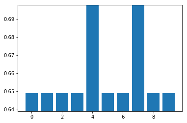

```python
import warnings
warnings.filterwarnings('ignore')
from matplotlib import pyplot as plt
from sklearn.model_selection import cross_val_score
from sklearn.model_selection import KFold, ShuffleSplit
from sklearn.model_selection import StratifiedKFold, StratifiedShuffleSplit

from sklearn.metrics import make_scorer, accuracy_score
from sklearn.metrics import precision_score, recall_score, f1_score

from sklearn.linear_model import LogisticRegression
# these imports above might help you

#=====Write your code below here=================
# select model
clf = LogisticRegression()
#select cross validation
cv = StratifiedShuffleSplit(n_splits=10,test_size=0.2)  #We use stratifiedKFold instead of KFold
# select evaluation criteria
my_scorer = make_scorer(f1_score,average='macro')                #We use f1 score instead of accuracy score
# run model training and cross validation
per_fold_eval_criteria = cross_val_score(estimator=clf,
                                    X=X,
                                    y=y,
                                    cv=cv,
                                    scoring=my_scorer
                                   )

plt.bar(range(len(per_fold_eval_criteria)),per_fold_eval_criteria)
plt.ylim([min(per_fold_eval_criteria)-0.01,max(per_fold_eval_criteria)])
```

```python
X=np.array(X)
y=np.array(y)
# for train_index, test_index in cv.split(X, y):
#         X_train, y_train = X[train_index], y[train_index]
#         X_test, y_test = X[test_index], y[test_index]
```

## Modeling

First, we will include the source code from Professor Larson's lecture

```python
# Example adapted from https://github.com/rasbt/python-machine-learning-book/blob/master/code/ch12/ch12.ipynb
# Original Author: Sebastian Raschka

# This is the optional book we use in the course, excellent intuitions and straightforward programming examples
# please note, however, that this code has been manipulated to reflect our assumptions and notation.
import numpy as np
from scipy.special import expit
import sys
import pandas as pd

# start with a simple base classifier, which can't be fit or predicted
# it only has internal classes to be used by classes that will subclass it
class TwoLayerPerceptronBase(object):
    def __init__(self, n_hidden=30,
                 C=0.0, epochs=500, eta=0.001, random_state=None):
        np.random.seed(random_state)
        self.n_hidden = n_hidden
        self.l2_C = C
        self.epochs = epochs
        self.eta = eta

    @staticmethod
    def _encode_labels(y):
        """Encode labels into one-hot representation"""
        onehot = pd.get_dummies(y).values.T

        return onehot

    def _initialize_weights(self):
        """Initialize weights with small random numbers."""
        W1_num_elems = (self.n_features_ + 1)*self.n_hidden
        W1 = np.random.uniform(-1.0, 1.0, size=W1_num_elems)
        W1 = W1.reshape(self.n_hidden, self.n_features_ + 1) # reshape to be W

        W2_num_elems = (self.n_hidden + 1)*self.n_output_
        W2 = np.random.uniform(-1.0, 1.0, size=W2_num_elems)
        W2 = W2.reshape(self.n_output_, self.n_hidden + 1)
        return W1, W2

    @staticmethod
    def _sigmoid(z):
        """Use scipy.special.expit to avoid overflow"""
        # 1.0 / (1.0 + np.exp(-z))
        return expit(z)

    @staticmethod
    def _add_bias_unit(X, how='column'):
        """Add bias unit (column or row of 1s) to array at index 0"""
        if how == 'column':
            ones = np.ones((X.shape[0], 1))
            X_new = np.hstack((ones, X))
        elif how == 'row':
            ones = np.ones((1, X.shape[1]))
            X_new = np.vstack((ones, X))
        return X_new

    @staticmethod
    def _L2_reg(lambda_, W1, W2):
        """Compute L2-regularization cost"""
        # only compute for non-bias terms
        return (lambda_/2.0) * np.sqrt(np.mean(W1[:, 1:] ** 2) + np.mean(W2[:, 1:] ** 2))

    def _cost(self,A3,Y_enc,W1,W2):
        '''Get the objective function value'''
        cost = np.mean((Y_enc-A3)**2)
        L2_term = self._L2_reg(self.l2_C, W1, W2)
        return cost + L2_term
```

```python
class TwoLayerPerceptron(TwoLayerPerceptronBase):
    def _feedforward(self, X, W1, W2):
        """Compute feedforward step
        -----------
        X : Input layer with original features.
        W1: Weight matrix for input layer -> hidden layer.
        W2: Weight matrix for hidden layer -> output layer.
        ----------
        a1-a3 : activations into layer (or output layer)
        z1-z2 : layer inputs

        """
        A1 = self._add_bias_unit(X.T, how='row')
        Z1 = W1 @ A1
        A2 = self._sigmoid(Z1)
        A2 = self._add_bias_unit(A2, how='row')
        Z2 = W2 @ A2
        A3 = self._sigmoid(Z2)
        return A1, Z1, A2, Z2, A3

    def _get_gradient(self, A1, A2, A3, Z1, Z2, Y_enc, W1, W2):
        """ Compute gradient step using backpropagation.
        """
        # backpropagation
        grad1 = np.zeros(W1.shape)
        grad2 = np.zeros(W2.shape)

        # for each instance's activations
        for (a1,a2,a3,y) in zip(A1.T,A2.T,A3.T,Y_enc.T):
            dJ_dz2 = -2*(y - a3)*a3*(1-a3)
            dJ_dz1 = dJ_dz2 @ W2 @ np.diag(a2*(1-a2))

            grad2 += dJ_dz2[:,np.newaxis]  @ a2[np.newaxis,:]
            grad1 += dJ_dz1[1:,np.newaxis] @ a1[np.newaxis,:]
            # don't incorporate bias term in the z1 gradient
            # (its added in a2 from another layer)


        # regularize weights that are not bias terms
        grad1[:, 1:] += (W1[:, 1:] * self.l2_C)
        grad2[:, 1:] += (W2[:, 1:] * self.l2_C)

        return grad1, grad2

    def predict(self, X):
        """Predict class labels"""
        _, _, _, _, A3 = self._feedforward(X, self.W1, self.W2)
        y_pred = np.argmax(A3, axis=0)
        return y_pred


    def fit(self, X, y, print_progress=False):
        """ Learn weights from training data."""

        X_data, y_data = X.copy(), y.copy()
        Y_enc = self._encode_labels(y)

        # init weights and setup matrices
        self.n_features_ = X_data.shape[1]
        self.n_output_ = Y_enc.shape[0]
        self.W1, self.W2 = self._initialize_weights()

        self.cost_ = []
        for i in range(self.epochs):

            if print_progress>0 and (i+1)%print_progress==0:
                sys.stderr.write('\rEpoch: %d/%d' % (i+1, self.epochs))
                sys.stderr.flush()

            # feedforward all instances
            A1, Z1, A2, Z2, A3 = self._feedforward(X_data,self.W1,self.W2)

            cost = self._cost(A3,Y_enc,self.W1,self.W2)
            self.cost_.append(cost)

            # compute gradient via backpropagation
            grad1, grad2 = self._get_gradient(A1=A1, A2=A2, A3=A3, Z1=Z1, Z2=Z2, Y_enc=Y_enc,
                                              W1=self.W1, W2=self.W2)

            self.W1 -= self.eta * grad1
            self.W2 -= self.eta * grad2


        return self
```

```python
params = dict(n_hidden=50,
              C=0.1, # tradeoff L2 regularizer
              epochs=200, # iterations
              eta=0.001,  # learning rate
              random_state=1)
```

```python
class TwoLayerPerceptronVectorized(TwoLayerPerceptron):
    # just need a different gradient calculation
    def _get_gradient(self, A1, A2, A3, Z1, Z2, Y_enc, W1, W2):
        """ Compute gradient step using backpropagation.
        """
        # vectorized backpropagation
        V2 = -2*(Y_enc-A3)*A3*(1-A3)
        V1 = A2*(1-A2)*(W2.T @ V2)

        grad2 = V2 @ A2.T
        grad1 = V1[1:,:] @ A1.T


        # regularize weights that are not bias terms
        grad1[:, 1:] += W1[:, 1:] * self.l2_C
        grad2[:, 1:] += W2[:, 1:] * self.l2_C

        return grad1, grad2
```

```python
from scipy.optimize import fmin_bfgs
from scipy.optimize import fmin_l_bfgs_b
class TLPVectorizedBFGS(TwoLayerPerceptronVectorized):

    def __init__(self, gtol=1e-5, **kwds):
        # need to add to the original initializer
        self.gtol = gtol

        # but keep other keywords
        super().__init__(**kwds)

    @staticmethod
    def _pack(in1, in2):
        '''Pack and flatten input vectors '''
        return np.hstack((in1.flatten(),in2.flatten()))

    def _unpack(self, in_tot):
        '''Undo packing according to layer weight sizes'''
        out1 = in_tot[:self.W1.size].reshape(self.W1.shape)
        out2 = in_tot[self.W1.size:].reshape(self.W2.shape)
        return out1, out2

    def _calc_cost_gradient_packed(self,W,X_data,Y_enc):
        '''Unpack and get cost, gradient for bfgs'''
        W1, W2 = self._unpack(W)
        # feedforward all instances
        A1, Z1, A2, Z2, A3 = self._feedforward(X_data,W1,W2)

        cost = np.sum((Y_enc-A3)**2)
        L2_term = self._L2_reg(self.l2_C, W1, W2)
        cost = cost + L2_term
        #perform back prop to get gradients
        grad1,grad2 = self._get_gradient(A1=A1, A2=A2, A3=A3,Z1=Z1, Z2=Z2, Y_enc=Y_enc,
                                         W1=W1, W2=W2)
        return cost, self._pack(grad1,grad2)

    def _cost_packed(self,W,X_data,Y_enc):
        '''Unpack and calculate MSE for bfgs'''
        W1, W2 = self._unpack(W)
        _, _, _, _, A3 = self._feedforward(X_data,W1,W2)
        return np.sum((Y_enc-A3)**2)

    def fit(self,X,y,print_progress=0):
        '''Learn weights from training data'''
        X_data, y_data = X.copy(), y.copy()
        Y_enc = self._encode_labels(y)

        # init weights and setup matrices
        self.n_features_ = X_data.shape[1]
        self.n_output_ = Y_enc.shape[0]
        self.W1, self.W2 = self._initialize_weights()

        # make initial matrices into single row vector
        W = self._pack(self.W1,self.W2)

        if print_progress>0:
            def callback(xd):
                callback.counter += 1
                if callback.counter%print_progress==0:
                    sys.stderr.write('\rEpoch: %d/%d (max)' % (callback.counter,callback.epochs))
                    sys.stderr.flush()

            callback.counter = 0
            callback.epochs = self.epochs

        else:
            callback = None

        # compute gradient optimum with bfgs
        W_best,_,props = fmin_l_bfgs_b(
                        x0=W,
                        func=self._calc_cost_gradient_packed,
                        maxfun=self.epochs,
                        callback=callback,
                        pgtol=self.gtol,
                        args=(X_data, Y_enc))

        self.W1, self.W2 = self._unpack(W_best)
        if print_progress:
            print(props)
```

Then we implement a function that can calculate the average score using the customized metrics among 10 folds that have been divided.

Next, we put the F1 score and accuracy score in the function to better express the performance. The only metrics used in this lab, to determine the performance, are the customized weighted accuracy metrics.

```python
%%time
nn_bfgs = TLPVectorizedBFGS(**params, gtol=1e-3)

import time

def my_func(method,X,y):
    f1_score_sum=0.0
    acc_sum=0.0
    weighted_acc_sum=0.0
    train_time=0.0
    pred_time=0.0
    for train_index, test_index in cv.split(X, y):
        X_train, y_train = X[train_index], y[train_index]
        X_test, y_test = X[test_index], y[test_index]

        t = time.time()
        method.fit(X_train, y_train)
        t = time.time() - t
        train_time+=t

        pred_t=time.time()
        yhat = method.predict(X_test)
        pred_t = time.time() - pred_t
        pred_time+=pred_t

        f1_score_sum+=f1_score(y_test, yhat, average='macro')
        acc_sum+=accuracy_score(y_test,yhat)
        weighted_acc_sum+=weighted_accuracy_score(y_test,yhat)
    return f1_score_sum/cv.get_n_splits(X),acc_sum/cv.get_n_splits(X),weighted_acc_sum/cv.get_n_splits(X),train_time/cv.get_n_splits(X),pred_time/cv.get_n_splits(X)


print(my_func(nn_bfgs,X,y))
```

```
(0.7893004115226339, 0.9713235294117647, 1.1433823529411764, 0.4393577575683594, 9.763240814208984e-05)
Wall time: 4.44 s
```

Here we see BFGS has a very good performance with our dataset

Then we implement the Multi-layer perceptron network. In the AdvancedMLP class, we can adjust the activation function, the cost function, and the hidden layers.

```python
class AdvancedMLP(TwoLayerPerceptronVectorized):
    def __init__(self, act='sigmoid',cost='quadratic',layer=2,**kwds):
        # need to add to the original initializer
        self.layer=layer+1  #Total Layer= Hidden layer+1
        self.act=act
        self.cost=cost
        self.W=[]
        self.gradient_epochs=[]
        # but keep other keywords
        super().__init__(**kwds)

    def _activation(self, z):
        if self.act == 'sigmoid':
            return self._sigmoid(z)
        else:
            return z/np.max(z)

    def _feedforward(self, X):
        A=[]
        Z=[]
        a = self._add_bias_unit(X.T, how='row')
        A.append(a)
        #A has one more element than Z, the last element is output
        for i in range(self.layer-1):
            z = self.W[i] @ a
            input_z=self._activation(z)
            a = self._add_bias_unit(input_z, how='row')
            A.append(a)
            Z.append(z)
        z = self.W[self.layer - 1] @ a #last layer
        a = self._sigmoid(z)                  #output
        A.append(a)
        Z.append(z)
        return A,Z

    def fit(self,X,y,print_progress=0):
        '''Learn weights from training data'''
        A=[]
        Z=[]
        X_data, y_data = X.copy(), y.copy()
        Y_enc = self._encode_labels(y)

        # init weights and setup matrices
        self.n_features_ = X_data.shape[1]
        self.n_output_ = Y_enc.shape[0]

        self.W=[]
        W1= self._initialize_weights()
        self.W.append(W1)
        for i in range (1,self.layer-1):
            W2=self._initialize_hidden_layer_weights()
            self.W.append(W2)
        W3=self._initialize_last_layer_weights()
        self.W.append(W3)

        for i in range(0,self.epochs):
            A,Z=self._feedforward(X_data)
            self.get_gradient(A,Z,Y_enc)
            for k in range(0,self.layer):
                self.gradient_epochs.append([])
            for k in range(0,self.layer):
                self.gradient_epochs[k].append((np.mean(np.abs(self.gradients[k]))))
            for j in range(self.layer):
                self.W[j] -= self.eta * self.gradients[j]

    def show_gradient(self):
        fig = plt.figure(figsize=(20,10))
        fig.suptitle('Gradient magnitude', fontsize=16)
        for i in range(self.layer):
            gradient_label='layer'+str(i+1)
            plt.plot(self.gradient_epochs[i][10:], label=gradient_label)
        plt.legend()
        plt.ylabel('Average gradient magnitude')
        plt.xlabel('Iteration')
        plt.show()


    def bp_activation(self,A):
        if self.act=="sigmoid":
            return A*(1-A)
        else:
#             for i in range(len(A)):
#                 for j in range(len(A[0])):
#                     A[i][j]=1
            return np.ones(A.shape)

    def get_gradient(self, A,Z, Y):
        self.gradients=self.W.copy()
        V=self.W.copy()

        l=self.layer-1

        if self.cost == 'quadratic':
            V[l] = -2 * (Y - A[l+1]) * (1 - A[l+1])
        else :
            V[l] = (A[l+1] - Y)

#         V2 = -2*(Y_enc-A3)*A3*(1-A3)
#         V1 = A2*(1-A2)*(W2.T @ V2)

#         grad2 = V2 @ A2.T
#         grad1 = V1[1:,:] @ A1.T

        self.gradients[l] = V[l] @ A[l].T
        self.gradients[l] += self.W[l] * self.l2_C

        l=l-1
        V[l] = (self.bp_activation(A[l+1])) * (self.W[l+1].T @ V[l+1])

        self.gradients[l] = V[l][1:,:] @ A[l].T
        self.gradients[l] += self.W[l] * self.l2_C

        for i in range(self.layer-3, 0, -1):
            V[i] =  self.bp_activation(A[l+1]) * (self.W[i+1].T @ V[i+1][1:,:])

            self.gradients[i] = V[i][1:,:] @ A[i].T
            self.gradients[i] += self.W[i] * self.l2_C

    def predict(self, X):
        """Predict class labels"""
        A,_ = self._feedforward(X)
        y_pred = np.argmax(A[self.layer], axis=0)
        return y_pred
    def _initialize_weights(self):
        """Initialize weights with small random numbers."""
        W1_num_elems = (self.n_features_ + 1)*self.n_hidden
        W1 = np.random.uniform(-1.0, 1.0, size=W1_num_elems)
        W1 = W1.reshape(self.n_hidden, self.n_features_ + 1) # reshape to be W

        return W1

    def _initialize_hidden_layer_weights(self):

        W2_num_elems = (self.n_hidden + 1)*self.n_hidden
        W2 = np.random.uniform(-1.0, 1.0, size=W2_num_elems)
        W2 = W2.reshape(self.n_hidden, self.n_hidden + 1)
        return W2

    def _initialize_last_layer_weights(self):
        """Initialize weights with small random numbers."""

        W2_num_elems = (self.n_hidden + 1)*self.n_output_
        W2 = np.random.uniform(-1.0, 1.0, size=W2_num_elems)
        W2 = W2.reshape(self.n_output_, self.n_hidden + 1)
        return W2
```

### Does time matter?

```python
params = dict(n_hidden=30,
              C=0.1, # tradeoff L2 regularizer
              epochs=250, # iterations
              eta=0.001,  # learning rate
              random_state=2)
a_mlp = AdvancedMLP(**params,layer=4,act='linear',cost="entropy")
_,_,_,train_time,predict_time=my_func(a_mlp,X,y)
print('Train time is: ',train_time,' Predict time is: ',predict_time)
```

```
Train time is:  0.633673882484436  Predict time is:  0.0005308151245117188
```

As we see the training time takes 0.64 second while predict time is relatively very small. In our business use, since we do not frequently retrain our model to incorporate with new red wine quality, we do not need to worry about train time. Also, with so mall predicting time cost, we do not need to worry about predicting time, either.

### Tune the hyperparameters

Now we will tune the hyperparameters, that is "datasnooping" the results using different combinations of parameters. We will tune the parameters of layers, activation functions, cost functions, hidden neurons, epochs and store the results in the array.

```python
h_layers=[3,4,5]
act=['linear','sigmoid']
cost=['quadratic','entropy']
n_hidden=[30,40,50]
epoch=[200,250,300]

params = dict(
               C=0.1, # tradeoff L2 regularizer
              eta=0.001,  # learning rate
              random_state=2)

l_list=[]
a_list=[]
c_list=[]
n_list=[]
e_list=[]
score_list=[]
for l in h_layers:
    for a in act:
        for c in cost:
            for n in n_hidden:
                for e in epoch:
                    a_mlp = AdvancedMLP(**params,layer=l,act=a,cost=c,n_hidden=n,epochs=e)
                    _,_,score,_,_=my_func(a_mlp,X,y)
                    l_list.append(l)
                    a_list.append(a)
                    c_list.append(c)
                    n_list.append(n)
                    e_list.append(e)
                    score_list.append(score)
                    print('MLP uses ',l,' hidden layers, ',a,' activation function, ',c,' cost function, ',n,' hidden neutrons, ',
                          e,' epoch, ',
                         score,' score')
```

```
MLP uses  3  hidden layers,  linear  activation function,  quadratic  cost function,  30  hidden neutrons,  200  epoch,  0.4584558823529411  score
MLP uses  3  hidden layers,  linear  activation function,  quadratic  cost function,  30  hidden neutrons,  250  epoch,  0.46691176470588236  score
MLP uses  3  hidden layers,  linear  activation function,  quadratic  cost function,  30  hidden neutrons,  300  epoch,  0.4595588235294118  score
MLP uses  3  hidden layers,  linear  activation function,  quadratic  cost function,  40  hidden neutrons,  200  epoch,  0.46691176470588225  score
MLP uses  3  hidden layers,  linear  activation function,  quadratic  cost function,  40  hidden neutrons,  250  epoch,  0.469485294117647  score
MLP uses  3  hidden layers,  linear  activation function,  quadratic  cost function,  40  hidden neutrons,  300  epoch,  0.4790441176470589  score
MLP uses  3  hidden layers,  linear  activation function,  quadratic  cost function,  50  hidden neutrons,  200  epoch,  0.468014705882353  score
MLP uses  3  hidden layers,  linear  activation function,  quadratic  cost function,  50  hidden neutrons,  250  epoch,  0.4779411764705882  score
MLP uses  3  hidden layers,  linear  activation function,  quadratic  cost function,  50  hidden neutrons,  300  epoch,  0.481985294117647  score
MLP uses  3  hidden layers,  linear  activation function,  entropy  cost function,  30  hidden neutrons,  200  epoch,  0.46397058823529413  score
MLP uses  3  hidden layers,  linear  activation function,  entropy  cost function,  30  hidden neutrons,  250  epoch,  0.46470588235294114  score
MLP uses  3  hidden layers,  linear  activation function,  entropy  cost function,  30  hidden neutrons,  300  epoch,  0.46875  score
MLP uses  3  hidden layers,  linear  activation function,  entropy  cost function,  40  hidden neutrons,  200  epoch,  0.46066176470588244  score
MLP uses  3  hidden layers,  linear  activation function,  entropy  cost function,  40  hidden neutrons,  250  epoch,  0.46507352941176466  score
MLP uses  3  hidden layers,  linear  activation function,  entropy  cost function,  40  hidden neutrons,  300  epoch,  0.4768382352941177  score
MLP uses  3  hidden layers,  linear  activation function,  entropy  cost function,  50  hidden neutrons,  200  epoch,  0.47316176470588234  score
MLP uses  3  hidden layers,  linear  activation function,  entropy  cost function,  50  hidden neutrons,  250  epoch,  0.4783088235294118  score
MLP uses  3  hidden layers,  linear  activation function,  entropy  cost function,  50  hidden neutrons,  300  epoch,  0.4801470588235294  score
MLP uses  3  hidden layers,  sigmoid  activation function,  quadratic  cost function,  30  hidden neutrons,  200  epoch,  0.4294117647058823  score
MLP uses  3  hidden layers,  sigmoid  activation function,  quadratic  cost function,  30  hidden neutrons,  250  epoch,  0.44558823529411756  score
MLP uses  3  hidden layers,  sigmoid  activation function,  quadratic  cost function,  30  hidden neutrons,  300  epoch,  0.456985294117647  score
MLP uses  3  hidden layers,  sigmoid  activation function,  quadratic  cost function,  40  hidden neutrons,  200  epoch,  0.41139705882352945  score
MLP uses  3  hidden layers,  sigmoid  activation function,  quadratic  cost function,  40  hidden neutrons,  250  epoch,  0.42169117647058824  score
MLP uses  3  hidden layers,  sigmoid  activation function,  quadratic  cost function,  40  hidden neutrons,  300  epoch,  0.4591911764705882  score
MLP uses  3  hidden layers,  sigmoid  activation function,  quadratic  cost function,  50  hidden neutrons,  200  epoch,  0.380514705882353  score
MLP uses  3  hidden layers,  sigmoid  activation function,  quadratic  cost function,  50  hidden neutrons,  250  epoch,  0.380514705882353  score
MLP uses  3  hidden layers,  sigmoid  activation function,  quadratic  cost function,  50  hidden neutrons,  300  epoch,  0.380514705882353  score
MLP uses  3  hidden layers,  sigmoid  activation function,  entropy  cost function,  30  hidden neutrons,  200  epoch,  0.4661764705882353  score
MLP uses  3  hidden layers,  sigmoid  activation function,  entropy  cost function,  30  hidden neutrons,  250  epoch,  0.4761029411764707  score
MLP uses  3  hidden layers,  sigmoid  activation function,  entropy  cost function,  30  hidden neutrons,  300  epoch,  0.48382352941176476  score
MLP uses  3  hidden layers,  sigmoid  activation function,  entropy  cost function,  40  hidden neutrons,  200  epoch,  0.5036764705882353  score
MLP uses  3  hidden layers,  sigmoid  activation function,  entropy  cost function,  40  hidden neutrons,  250  epoch,  0.5113970588235294  score
MLP uses  3  hidden layers,  sigmoid  activation function,  entropy  cost function,  40  hidden neutrons,  300  epoch,  0.5231617647058824  score
MLP uses  3  hidden layers,  sigmoid  activation function,  entropy  cost function,  50  hidden neutrons,  200  epoch,  0.463235294117647  score
MLP uses  3  hidden layers,  sigmoid  activation function,  entropy  cost function,  50  hidden neutrons,  250  epoch,  0.4669117647058824  score
MLP uses  3  hidden layers,  sigmoid  activation function,  entropy  cost function,  50  hidden neutrons,  300  epoch,  0.4742647058823529  score
MLP uses  4  hidden layers,  linear  activation function,  quadratic  cost function,  30  hidden neutrons,  200  epoch,  0.45294117647058824  score
MLP uses  4  hidden layers,  linear  activation function,  quadratic  cost function,  30  hidden neutrons,  250  epoch,  0.45735294117647063  score
MLP uses  4  hidden layers,  linear  activation function,  quadratic  cost function,  30  hidden neutrons,  300  epoch,  0.46360294117647055  score
MLP uses  4  hidden layers,  linear  activation function,  quadratic  cost function,  40  hidden neutrons,  200  epoch,  0.48014705882352937  score
```

[output cut: 53 more lines]

```
MLP uses  5  hidden layers,  sigmoid  activation function,  quadratic  cost function,  40  hidden neutrons,  200  epoch,  0.38161764705882356  score
MLP uses  5  hidden layers,  sigmoid  activation function,  quadratic  cost function,  40  hidden neutrons,  250  epoch,  0.3889705882352941  score
MLP uses  5  hidden layers,  sigmoid  activation function,  quadratic  cost function,  40  hidden neutrons,  300  epoch,  0.4172794117647059  score
MLP uses  5  hidden layers,  sigmoid  activation function,  quadratic  cost function,  50  hidden neutrons,  200  epoch,  0.37205882352941183  score
MLP uses  5  hidden layers,  sigmoid  activation function,  quadratic  cost function,  50  hidden neutrons,  250  epoch,  0.37205882352941183  score
MLP uses  5  hidden layers,  sigmoid  activation function,  quadratic  cost function,  50  hidden neutrons,  300  epoch,  0.37205882352941183  score
MLP uses  5  hidden layers,  sigmoid  activation function,  entropy  cost function,  30  hidden neutrons,  200  epoch,  0.4455882352941177  score
MLP uses  5  hidden layers,  sigmoid  activation function,  entropy  cost function,  30  hidden neutrons,  250  epoch,  0.44522058823529403  score
MLP uses  5  hidden layers,  sigmoid  activation function,  entropy  cost function,  30  hidden neutrons,  300  epoch,  0.44338235294117645  score
MLP uses  5  hidden layers,  sigmoid  activation function,  entropy  cost function,  40  hidden neutrons,  200  epoch,  0.4352941176470589  score
MLP uses  5  hidden layers,  sigmoid  activation function,  entropy  cost function,  40  hidden neutrons,  250  epoch,  0.43786764705882353  score
MLP uses  5  hidden layers,  sigmoid  activation function,  entropy  cost function,  40  hidden neutrons,  300  epoch,  0.4397058823529411  score
MLP uses  5  hidden layers,  sigmoid  activation function,  entropy  cost function,  50  hidden neutrons,  200  epoch,  0.438235294117647  score
MLP uses  5  hidden layers,  sigmoid  activation function,  entropy  cost function,  50  hidden neutrons,  250  epoch,  0.4397058823529411  score
MLP uses  5  hidden layers,  sigmoid  activation function,  entropy  cost function,  50  hidden neutrons,  300  epoch,  0.44558823529411756  score
```

```python
from mpl_toolkits import mplot3d
%matplotlib inline
import matplotlib.pyplot as plt

def plot_performance(x1,y1,x2,y2,z):
    fig = plt.figure(figsize=(20,10))
    fig.suptitle('1. method score versus layer and hidden neutrons 2. method score versus layer and epoch')
    ax = fig.add_subplot(1,2,1,projection='3d')
    plt.title('Score')
    ax.scatter3D(x1, y1, z,
                 cmap='viridis', edgecolor='none');
    ax.set_xlabel('layer')
    ax.set_ylabel('hidden neutrons')
    ax.set_zlabel('score');

    ax = fig.add_subplot(1,2,2,projection='3d')
    plt.title('Score')
    ax.scatter3D(x2, y2, z,
                 cmap='viridis', edgecolor='none');
    ax.set_xlabel('layer')
    ax.set_ylabel('epoch')
    ax.set_zlabel('score');
```

### Visualization

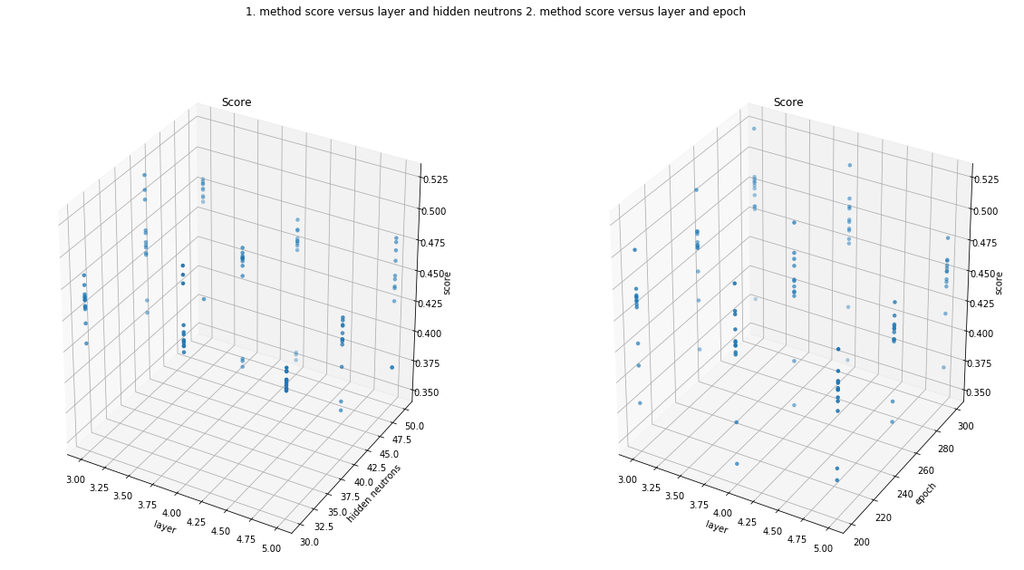

```python
plot_performance(np.array(l_list),np.array(n_list),np.array(l_list),np.array(e_list),
                 np.array(score_list))
```

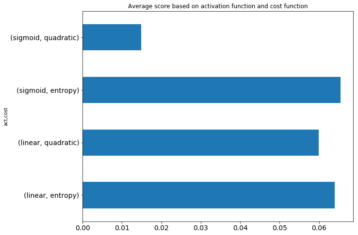

```python
import pandas as pd
res = zip(a_list,c_list,score_list)
df = pd.DataFrame(res,columns=["act","cost","score"])

df_new=df.groupby(by=['act','cost'])['score'].mean()-0.4    #-0.4 in order to zoom in the difference among functions
ax = df_new.plot(kind='barh',fontsize=14, figsize=(10,8))
plt.title('Average score based on activation function and cost function')
plt.show()
```

I substract 0.4 from the average score to better visualize the difference in performance.It turns out using sigmoid and cross-entropy has the best performance, and the combination of sigmoid activation function and quadratic cost function performs poorly

Below is the best performance we have and the parameters used to build the MLP

```python
i=score_list.index(max(score_list))
print('MLP uses ',l_list[i],' hidden layers, ',a_list[i],' activation function, ',
                          c_list[i],' cost function, ',
                          n_list[i],' hidden neutrons, ',
                          e_list[i],' epoch, ',
                         score_list[i],' score')
```

```
MLP uses  3  hidden layers,  sigmoid  activation function,  entropy  cost function,  40  hidden neutrons,  300  epoch,  0.5231617647058824  score
```

### Visualization of gradient magnitude

Since we are tracking gradient, instead of using the 10 folds I divede for tuning the hyperparameters, I just use the entire X,y data because we just want to track the gradient and not predict yhat.

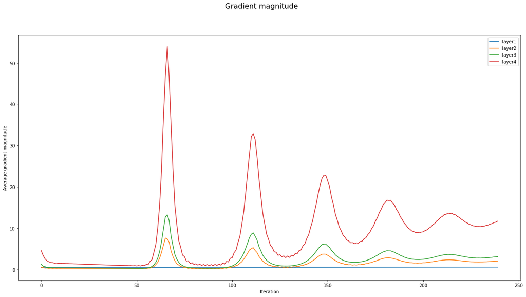

```python
params = dict(n_hidden=30,
              C=0.1, # tradeoff L2 regularizer
              epochs=250, # iterations
              eta=0.001,  # learning rate
              random_state=2)
a_mlp = AdvancedMLP(**params,layer=3,act='sigmoid',cost="entropy")
a_mlp.fit(X,y)
a_mlp.show_gradient()
```

## Extra

Implement two more phi functions: ReLU and SiLU (also called Swish). Compare their performance to the linear and sigmoid phi functions.

```python
class More_AdvancedMLP(AdvancedMLP):

    def _activation(self, z):
        if self.act == 'sigmoid':
            return self._sigmoid(z)
        elif self.act == 'linear':
            return z/np.max(z)
        elif self.act == 'relu':
            return z*(z>0)/np.max(z)
        elif self.act == 'silu':
            return z*self._sigmoid(z)/np.max(z)
        else:
            return z

    def bp_activation(self,A):
        if self.act=='sigmoid':
            return A*(1-A)
        elif self.act=='linear':
            return np.ones(A.shape)
        elif self.act=='relu':
            return np.ones(A.shape)
        elif self.act == 'silu':
            return A*self._sigmoid(A)+self._sigmoid(1-A*self._sigmoid(A))
        else:
            return A
```

```python
n_layers=[3,4,5]
act=['linear','sigmoid','relu','silu']
cost=['quadratic','entropy']
epoch=[200,250,300]

params = dict(
               C=0.1, # tradeoff L2 regularizer
              eta=0.001,  # learning rate
                n_hidden=40,
              random_state=2)

l_list=[]
a_list=[]
c_list=[]
e_list=[]
score_list=[]
for l in n_layers:
    for a in act:
        for c in cost:
            for e in epoch:
                ma_mlp = More_AdvancedMLP(**params,layer=l,act=a,cost=c,epochs=e)
                _,_,score,_,_=my_func(ma_mlp,X,y)
                l_list.append(l)
                a_list.append(a)
                c_list.append(c)
                e_list.append(e)
                score_list.append(score)
                print('MLP uses ',l,' hidden layers, ',a,' activation function, ',c,' cost function, ',40,' hidden neutrons, ',
                        e,' epoch, ',
                        score,' score')
```

```
MLP uses  3  hidden layers,  linear  activation function,  quadratic  cost function,  40  hidden neutrons,  200  epoch,  0.46691176470588225  score
MLP uses  3  hidden layers,  linear  activation function,  quadratic  cost function,  40  hidden neutrons,  250  epoch,  0.469485294117647  score
MLP uses  3  hidden layers,  linear  activation function,  quadratic  cost function,  40  hidden neutrons,  300  epoch,  0.4790441176470589  score
MLP uses  3  hidden layers,  linear  activation function,  entropy  cost function,  40  hidden neutrons,  200  epoch,  0.46066176470588244  score
MLP uses  3  hidden layers,  linear  activation function,  entropy  cost function,  40  hidden neutrons,  250  epoch,  0.46507352941176466  score
MLP uses  3  hidden layers,  linear  activation function,  entropy  cost function,  40  hidden neutrons,  300  epoch,  0.4768382352941177  score
MLP uses  3  hidden layers,  sigmoid  activation function,  quadratic  cost function,  40  hidden neutrons,  200  epoch,  0.41139705882352945  score
MLP uses  3  hidden layers,  sigmoid  activation function,  quadratic  cost function,  40  hidden neutrons,  250  epoch,  0.42169117647058824  score
MLP uses  3  hidden layers,  sigmoid  activation function,  quadratic  cost function,  40  hidden neutrons,  300  epoch,  0.4591911764705882  score
MLP uses  3  hidden layers,  sigmoid  activation function,  entropy  cost function,  40  hidden neutrons,  200  epoch,  0.5036764705882353  score
MLP uses  3  hidden layers,  sigmoid  activation function,  entropy  cost function,  40  hidden neutrons,  250  epoch,  0.5113970588235294  score
MLP uses  3  hidden layers,  sigmoid  activation function,  entropy  cost function,  40  hidden neutrons,  300  epoch,  0.5231617647058824  score
MLP uses  3  hidden layers,  relu  activation function,  quadratic  cost function,  40  hidden neutrons,  200  epoch,  0.45367647058823535  score
MLP uses  3  hidden layers,  relu  activation function,  quadratic  cost function,  40  hidden neutrons,  250  epoch,  0.44485294117647056  score
MLP uses  3  hidden layers,  relu  activation function,  quadratic  cost function,  40  hidden neutrons,  300  epoch,  0.44963235294117654  score
MLP uses  3  hidden layers,  relu  activation function,  entropy  cost function,  40  hidden neutrons,  200  epoch,  0.45330882352941176  score
MLP uses  3  hidden layers,  relu  activation function,  entropy  cost function,  40  hidden neutrons,  250  epoch,  0.4558823529411765  score
MLP uses  3  hidden layers,  relu  activation function,  entropy  cost function,  40  hidden neutrons,  300  epoch,  0.4555147058823529  score
MLP uses  3  hidden layers,  silu  activation function,  quadratic  cost function,  40  hidden neutrons,  200  epoch,  0.44338235294117645  score
MLP uses  3  hidden layers,  silu  activation function,  quadratic  cost function,  40  hidden neutrons,  250  epoch,  0.4466911764705882  score
MLP uses  3  hidden layers,  silu  activation function,  quadratic  cost function,  40  hidden neutrons,  300  epoch,  0.4485294117647058  score
MLP uses  3  hidden layers,  silu  activation function,  entropy  cost function,  40  hidden neutrons,  200  epoch,  0.4448529411764707  score
MLP uses  3  hidden layers,  silu  activation function,  entropy  cost function,  40  hidden neutrons,  250  epoch,  0.44595588235294115  score
MLP uses  3  hidden layers,  silu  activation function,  entropy  cost function,  40  hidden neutrons,  300  epoch,  0.4477941176470588  score
MLP uses  4  hidden layers,  linear  activation function,  quadratic  cost function,  40  hidden neutrons,  200  epoch,  0.48014705882352937  score
MLP uses  4  hidden layers,  linear  activation function,  quadratic  cost function,  40  hidden neutrons,  250  epoch,  0.4794117647058824  score
MLP uses  4  hidden layers,  linear  activation function,  quadratic  cost function,  40  hidden neutrons,  300  epoch,  0.48014705882352937  score
MLP uses  4  hidden layers,  linear  activation function,  entropy  cost function,  40  hidden neutrons,  200  epoch,  0.4658088235294118  score
MLP uses  4  hidden layers,  linear  activation function,  entropy  cost function,  40  hidden neutrons,  250  epoch,  0.47389705882352934  score
MLP uses  4  hidden layers,  linear  activation function,  entropy  cost function,  40  hidden neutrons,  300  epoch,  0.48161764705882354  score
MLP uses  4  hidden layers,  sigmoid  activation function,  quadratic  cost function,  40  hidden neutrons,  200  epoch,  0.3915441176470589  score
MLP uses  4  hidden layers,  sigmoid  activation function,  quadratic  cost function,  40  hidden neutrons,  250  epoch,  0.39632352941176474  score
MLP uses  4  hidden layers,  sigmoid  activation function,  quadratic  cost function,  40  hidden neutrons,  300  epoch,  0.3981617647058824  score
MLP uses  4  hidden layers,  sigmoid  activation function,  entropy  cost function,  40  hidden neutrons,  200  epoch,  0.4775735294117648  score
MLP uses  4  hidden layers,  sigmoid  activation function,  entropy  cost function,  40  hidden neutrons,  250  epoch,  0.48419117647058824  score
MLP uses  4  hidden layers,  sigmoid  activation function,  entropy  cost function,  40  hidden neutrons,  300  epoch,  0.4882352941176471  score
MLP uses  4  hidden layers,  relu  activation function,  quadratic  cost function,  40  hidden neutrons,  200  epoch,  0.4466911764705882  score
MLP uses  4  hidden layers,  relu  activation function,  quadratic  cost function,  40  hidden neutrons,  250  epoch,  0.45  score
MLP uses  4  hidden layers,  relu  activation function,  quadratic  cost function,  40  hidden neutrons,  300  epoch,  0.45367647058823535  score
MLP uses  4  hidden layers,  relu  activation function,  entropy  cost function,  40  hidden neutrons,  200  epoch,  0.45  score
```

[output cut: 17 more lines]

```
MLP uses  5  hidden layers,  sigmoid  activation function,  entropy  cost function,  40  hidden neutrons,  200  epoch,  0.4352941176470589  score
MLP uses  5  hidden layers,  sigmoid  activation function,  entropy  cost function,  40  hidden neutrons,  250  epoch,  0.43786764705882353  score
MLP uses  5  hidden layers,  sigmoid  activation function,  entropy  cost function,  40  hidden neutrons,  300  epoch,  0.4397058823529411  score
MLP uses  5  hidden layers,  relu  activation function,  quadratic  cost function,  40  hidden neutrons,  200  epoch,  0.4272058823529412  score
MLP uses  5  hidden layers,  relu  activation function,  quadratic  cost function,  40  hidden neutrons,  250  epoch,  0.43014705882352944  score
MLP uses  5  hidden layers,  relu  activation function,  quadratic  cost function,  40  hidden neutrons,  300  epoch,  0.432720588235294  score
MLP uses  5  hidden layers,  relu  activation function,  entropy  cost function,  40  hidden neutrons,  200  epoch,  0.43161764705882355  score
MLP uses  5  hidden layers,  relu  activation function,  entropy  cost function,  40  hidden neutrons,  250  epoch,  0.4294117647058823  score
MLP uses  5  hidden layers,  relu  activation function,  entropy  cost function,  40  hidden neutrons,  300  epoch,  0.4275735294117647  score
MLP uses  5  hidden layers,  silu  activation function,  quadratic  cost function,  40  hidden neutrons,  200  epoch,  0.4360294117647059  score
MLP uses  5  hidden layers,  silu  activation function,  quadratic  cost function,  40  hidden neutrons,  250  epoch,  0.4367647058823529  score
MLP uses  5  hidden layers,  silu  activation function,  quadratic  cost function,  40  hidden neutrons,  300  epoch,  0.43933823529411764  score
MLP uses  5  hidden layers,  silu  activation function,  entropy  cost function,  40  hidden neutrons,  200  epoch,  0.4352941176470588  score
MLP uses  5  hidden layers,  silu  activation function,  entropy  cost function,  40  hidden neutrons,  250  epoch,  0.4283088235294118  score
MLP uses  5  hidden layers,  silu  activation function,  entropy  cost function,  40  hidden neutrons,  300  epoch,  0.4345588235294118  score
```

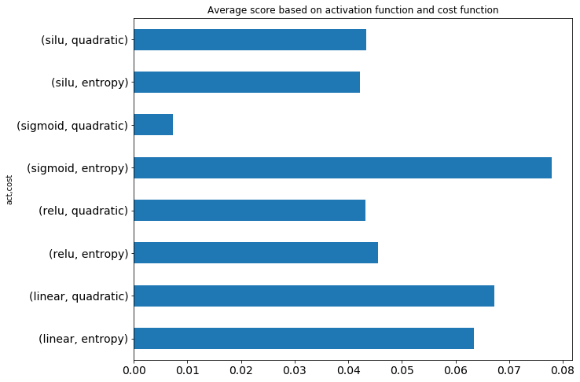

```python
res = zip(a_list,c_list,score_list)
df = pd.DataFrame(res,columns=["act","cost","score"])

df_new=df.groupby(by=['act','cost'])['score'].mean()-0.40   #-0.4 in order to zoom in the difference among functions
ax = df_new.plot(kind='barh',fontsize=14, figsize=(10,8))
plt.title('Average score based on activation function and cost function')
plt.show()
```

```python
df.groupby(by=['act','cost'])['score'].mean()
```

```
act      cost
linear   entropy      0.463480
         quadratic    0.467198
relu     entropy      0.445507
         quadratic    0.443178
sigmoid  entropy      0.477900
         quadratic    0.407353
silu     entropy      0.442157
         quadratic    0.443382
Name: score, dtype: float64
```

As depicted by the graph, the sigmoid function with entropy exceeds the average score of all other methods. Comes next is linear function using quadratic function..

Relu and Silu are not performing very well in our dataset. One of the benefit of using ReLU is reducing likelihood of the gradient to vanish, but we are using only a small number of hidden layers to get the performance result when Sigmoid might not have a serious vanishing gradient problem. Silu performs better in even deeper network. According to **https://medium.com/@neuralnets/swish-activation-function-by-google-53e1ea86f820**, "Swish outperforms ReLU by a large margin in the range between 40 and 50 layers when optimization becomes difficult. In very deep networks, Swish achieves higher test accuracy than ReLU."